# Exercices Session III: Description and between-group comparisons

Applied Biostatistics Course with R

Author

Biostatistics Support and Research Unit, IGTP

**Note**

The DIVINE project contains data collected from subjects hospitalized in 5 hospitals in the southern metropolitan area of Barcelona during four waves of COVID-19. The `divine` dataset included in this exercise is a random sample of 1000 patients with some selected information from the 1st and 5th waves.

**1.** Read the `divine.xlsx` excel.

```r
library(readxl)
divine <- read_excel("Data/divine.xlsx")
```

**2.** Find:

1. The minimum, 1st quartile (25th percentile), median, mean, 3rd quartile (75th percentile) and maximum of each numerical variable. Also report the missing values for these variables.

**Tip**

The `summary()` function returns all these basic descriptive statistics, along with the number of missing values.

```r
library(dplyr)
divine |>
  select(age, weight, height, total_leukocytes, hemoglobin, c_reactive_protein) |>
  summary()
```

```
      age            weight           height      total_leukocytes
 Min.   :19.00   Min.   : 42.00   Min.   :135.0   Min.   : 1.09
 1st Qu.:50.00   1st Qu.: 69.85   1st Qu.:158.0   1st Qu.: 4.90
 Median :64.00   Median : 77.80   Median :165.0   Median : 6.50
 Mean   :62.39   Mean   : 79.57   Mean   :164.9   Mean   : 7.23
 3rd Qu.:75.00   3rd Qu.: 89.00   3rd Qu.:172.0   3rd Qu.: 8.70
 Max.   :99.00   Max.   :130.00   Max.   :198.0   Max.   :32.00
                 NA's   :182      NA's   :199     NA's   :51
   hemoglobin    c_reactive_protein
 Min.   : 8.10   Min.   :  0.80
 1st Qu.:12.50   1st Qu.: 36.15
 Median :13.70   Median : 74.40
 Mean   :13.55   Mean   :101.29
 3rd Qu.:14.70   3rd Qu.:145.85
 Max.   :18.40   Max.   :508.10
 NA's   :58      NA's   :73
```

2. Based on these values, which numerical variables are non-normally distributed?

**Tip**

Normally distributed variables should have a median close to the mean. If we find differences, it means that the variable is not normal.

Leukocytes and PCR do not distribute normally.

3. Use QQ-Plot to confirm that the other variables are normally distributed.

**Tip**

Normally distributed variables should have points near the diagonal line.

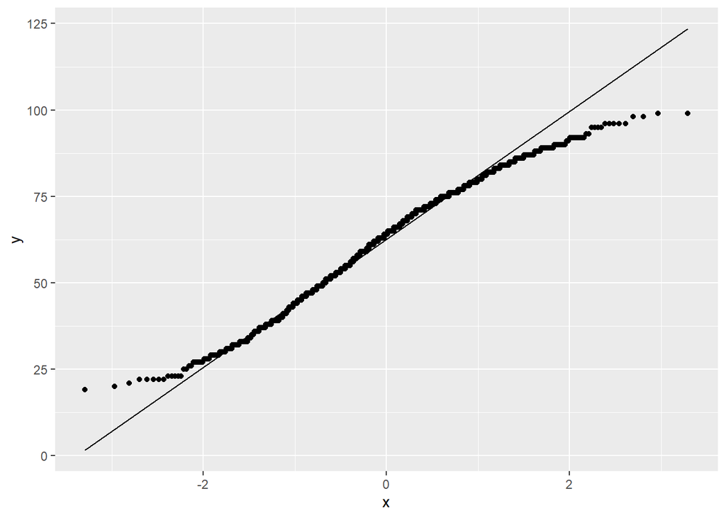

```r
library(ggplot2)

#Age
ggplot(data = divine, aes(sample = age)) +
  stat_qq() +
  stat_qq_line()
```

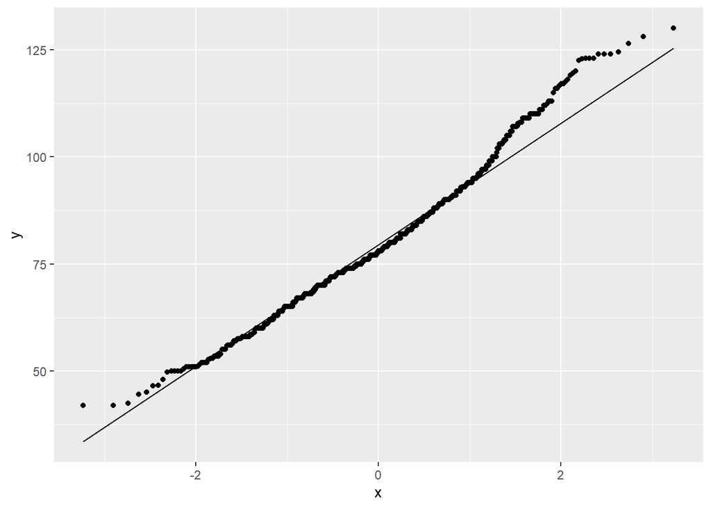

```r
#Weight
ggplot(data = divine, aes(sample = weight)) +
  stat_qq() +
  stat_qq_line()
```

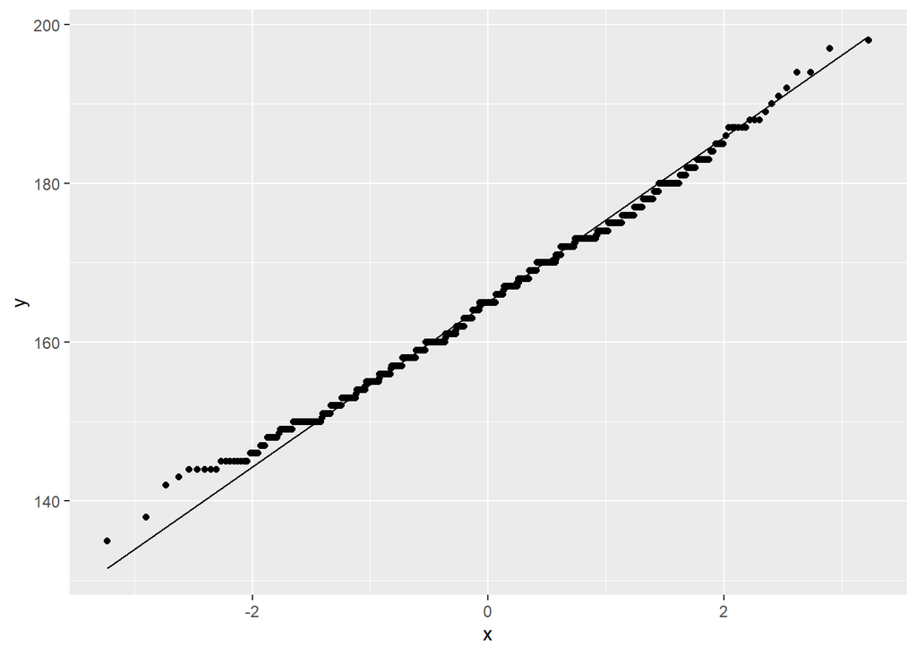

```r
#Height
ggplot(data = divine, aes(sample = height)) +
  stat_qq() +
  stat_qq_line()
```

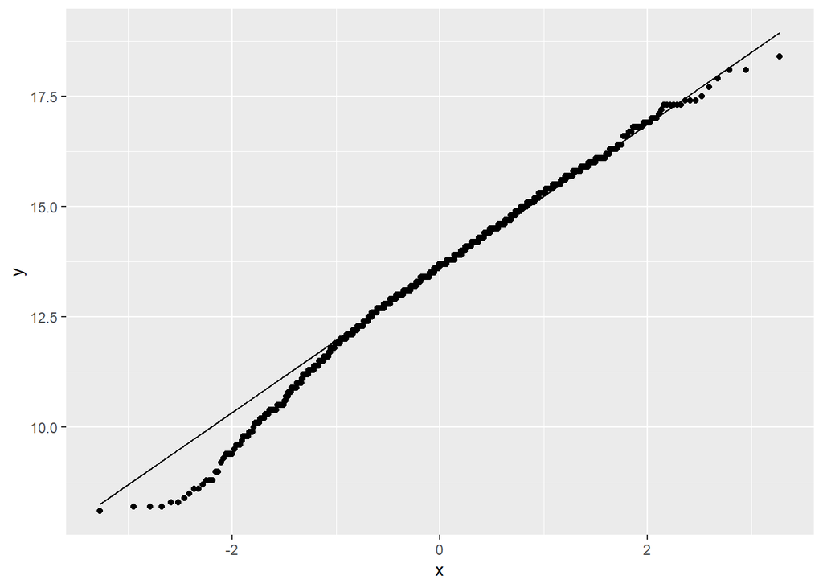

```r
#Hemoglobin
ggplot(data = divine, aes(sample = hemoglobin)) +
  stat_qq() +
  stat_qq_line()
```

**3.** Describe all the variables stored in this dataset by COVID-19 wave. Report missing values, insert the appropriate labels for each variable, and choose the appropriate statistic for each numeric variable.

**Tip**

tbl_summary() allows you to create a description table for your data. We can change the default labels and statistics with the `label` and `statistic` functions. Remember to use the syntax below:

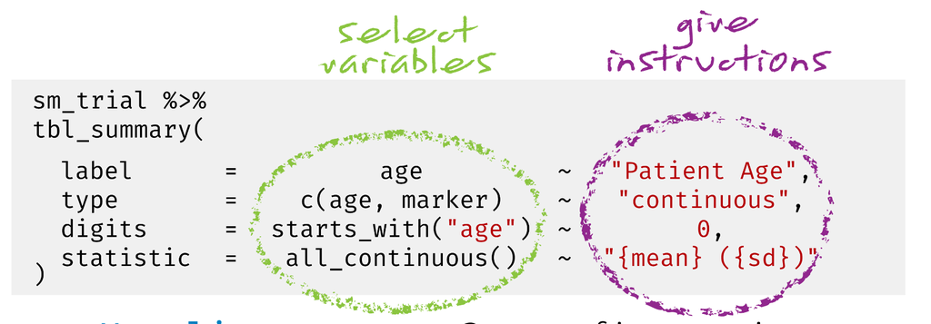

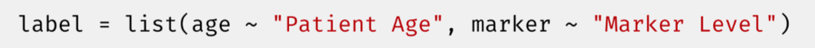

```r
library(gtsummary)

divine |>
  tbl_summary(
    include = -record_id,
    by = covid_wave,
    label = list(
      center ~ "Hospital",
      sex ~ "Sex",
      age ~ "Age",
      weight ~ "Weight",
      height ~ "Height",
      obesity ~ "Obesity",
      dm ~ "Diabetes mellitus",
      total_leukocytes ~ "Total leukocytes",
      hemoglobin ~ "Hemoglobin",
      c_reactive_protein ~ "PCR"
    ),
    statistic = list(
      age ~ "{mean} ({sd})",
      weight ~ "{mean} ({sd})",
      height ~ "{mean} ({sd})",
      hemoglobin ~ "{mean} ({sd})"
    )
  )
```

| **Characteristic** | **1st wave** N = 643<sup>1</sup> | **5th wave** N = 357<sup>1</sup> |
| --- | --- | --- |
| Hospital |  |  |
| Hospital A | 175 (27%) | 104 (29%) |
| Hospital B | 468 (73%) | 253 (71%) |
| Sex |  |  |
| Female | 253 (39%) | 145 (41%) |
| Male | 390 (61%) | 212 (59%) |
| Age | 64 (15) | 59 (20) |
| Weight | 79 (15) | 81 (17) |
| Unknown | 99 | 83 |
| Height | 165 (9) | 165 (11) |
| Unknown | 117 | 82 |
| Obesity | 187 (36%) | 115 (32%) |
| Unknown | 119 | 0 |
| Diabetes mellitus | 172 (27%) | 66 (18%) |
| Total leukocytes | 6.4 (4.9, 8.6) | 6.6 (4.7, 8.9) |
| Unknown | 42 | 9 |
| Hemoglobin | 13.55 (1.74) | 13.54 (1.87) |
| Unknown | 49 | 9 |
| PCR | 71 (35, 147) | 82 (37, 145) |
| Unknown | 59 | 14 |

<sup>1</sup> n (%); Mean (SD); Median (Q1, Q3)

**4.** Compare the proportion of diabetes mellitus by wave:

1. Perform a graphical comparison.

**Tip**

To compare a proportion between groups, it is useful to use the `position = "fill"` argument of the `geom_bar()` function.

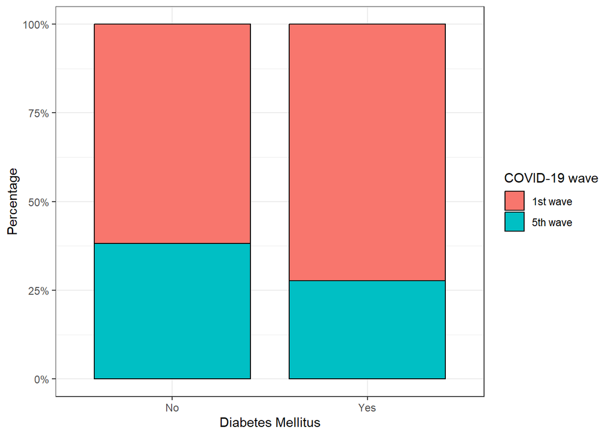

```r
ggplot(data = divine, aes(x = dm, fill = covid_wave)) +
  geom_bar(color = "black", width = .8, position = "fill") +
  scale_x_discrete(name = "Diabetes Mellitus") +
  scale_y_continuous(name = "Percentage", labels = scales::percent) +
  scale_fill_discrete(name = "COVID-19 wave") +
  theme_bw()
```

2. Perform the appropriate test to determine whether these differences are significant.

```r
chisq.test(x = divine$covid_wave, y = divine$dm)
```

```
    Pearson's Chi-squared test with Yates' continuity correction

data:  divine$covid_wave and divine$dm
X-squared = 8.191, df = 1, p-value = 0.00421
```

**5.** Compare the age distribution by wave:

1. Perform a graphical comparison using a density plot.

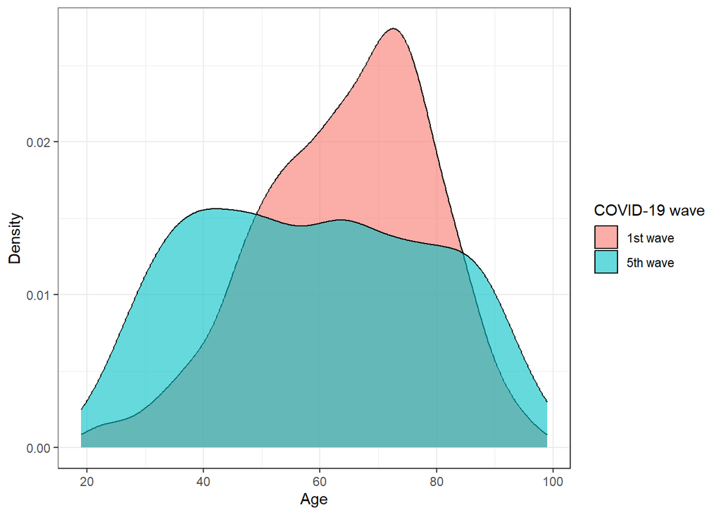

```r
ggplot(data = divine, aes(x = age, fill = covid_wave)) +
  geom_density(alpha = .6) +
  xlab("Age") +
  scale_y_continuous(name = "Density") +
  scale_fill_discrete(name = "COVID-19 wave") +
  theme_bw()
```

2. Repeat it using a box plot.

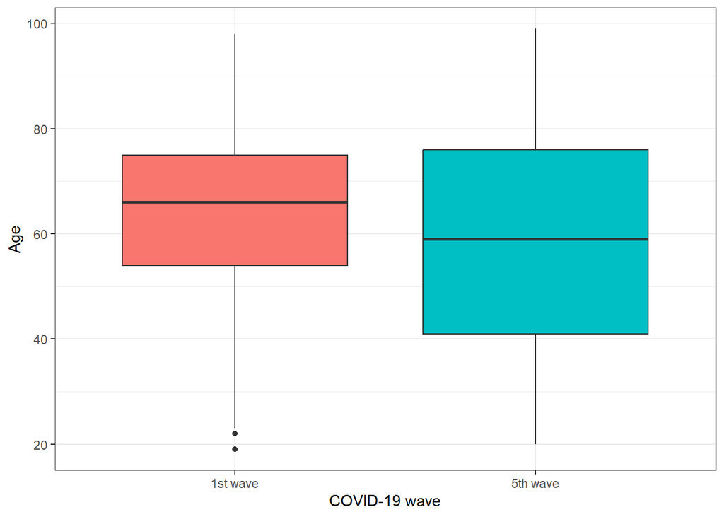

```r
ggplot(data = divine, aes(x = covid_wave, y = age, fill = covid_wave)) +
  geom_boxplot() +
  scale_x_discrete(name = "COVID-19 wave") +
  scale_y_continuous(name = "Age") +
  theme_bw()  +
  theme(legend.position="none")
```

3. Perform the appropriate test to determine whether there are differences in age between groups.

**Tip**

Check the QQ-plot to determine if this numerical variable is normally distributed or not.

```r
t.test(age ~ covid_wave, data = divine)
```

```
    Welch Two Sample t-test

data:  age by covid_wave
t = 4.6067, df = 575.08, p-value = 5.04e-06
alternative hypothesis: true difference in means between group 1st wave and group 5th wave is not equal to 0
95 percent confidence interval:
 3.197687 7.950920
sample estimates:
mean in group 1st wave mean in group 5th wave
              64.38103               58.80672
```

**6.** Compare the total leukocytes by wave:

1. Perform a graphical comparison using a density plot.

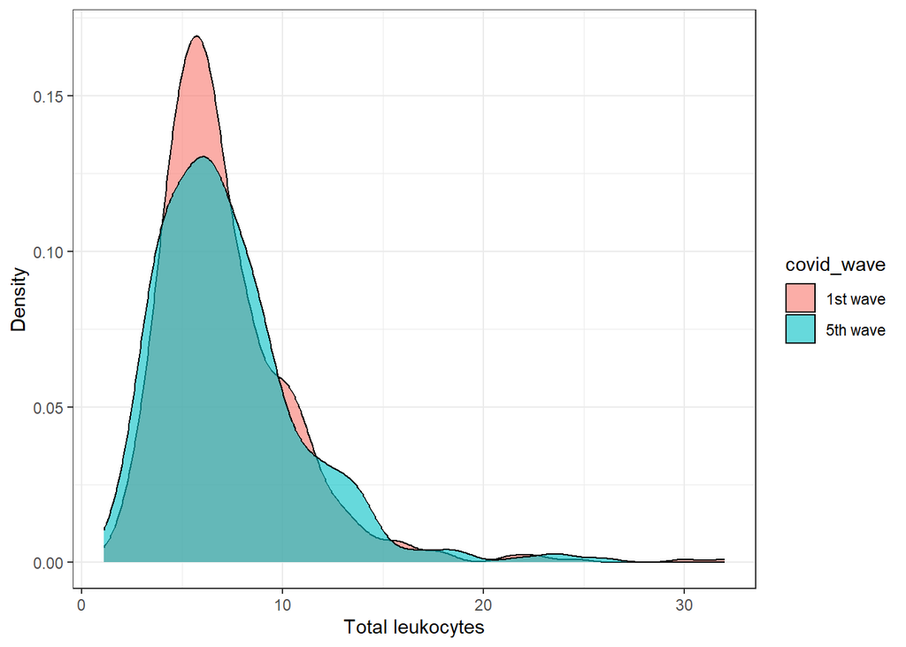

```r
ggplot(data = divine, aes(x = total_leukocytes, fill = covid_wave)) +
  geom_density(alpha = .6) +
  xlab("Total leukocytes") +
  scale_y_continuous(name = "Density") +
  theme_bw()
```

2. Repeat it using a box plot.

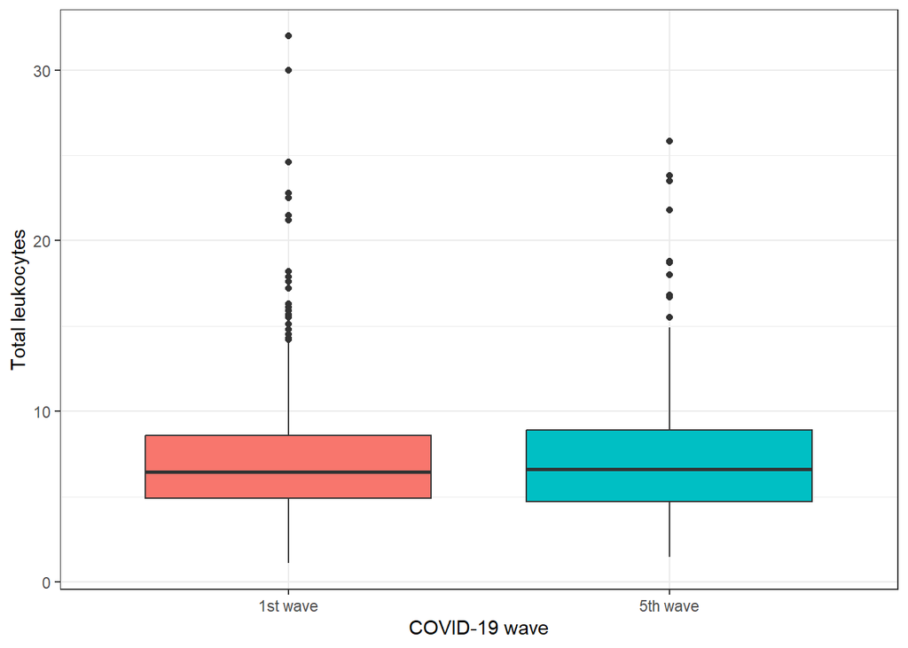

```r
ggplot(data = divine, aes(x = covid_wave, y = total_leukocytes, fill = covid_wave)) +
  geom_boxplot() +
  scale_x_discrete(name = "COVID-19 wave") +
  scale_y_continuous(name = "Total leukocytes") +
  theme_bw() +
  theme(legend.position="none")
```

3. Perform the appropriate test to determine whether these differences are significant.

**Tip**

Check the QQ-plot to determine if this numerical variable is normally distributed or not.

```r
wilcox.test(total_leukocytes ~ covid_wave, data = divine)
```

```
    Wilcoxon rank sum test with continuity correction

data:  total_leukocytes by covid_wave
W = 103198, p-value = 0.7352
alternative hypothesis: true location shift is not equal to 0
```

**7.** Perform a comparison test on all variables as a function of the wave and add it to the table.

**Tip**

Use the `add_p()` function after using the `tbl_summary()` function previously used to create the table.

```r
library(gtsummary)

divine |>
  tbl_summary(
    include = -record_id,
    by = covid_wave,
    label = list(
      center ~ "Hospital",
      sex ~ "Sex",
      age ~ "Age",
      weight ~ "Weight",
      height ~ "Height",
      obesity ~ "Obesity",
      dm ~ "Diabetes mellitus",
      total_leukocytes ~ "Total leukocytes",
      hemoglobin ~ "Hemoglobin",
      c_reactive_protein ~ "PCR"
    ),
    statistic = list(
      age ~ "{mean} ({sd})",
      weight ~ "{mean} ({sd})",
      height ~ "{mean} ({sd})",
      hemoglobin ~ "{mean} ({sd})"
    )
  ) |>
  add_p(
    test = c(age, weight, height, hemoglobin) ~ "t.test"
  )
```

| **Characteristic** | **1st wave** N = 643<sup>1</sup> | **5th wave** N = 357<sup>1</sup> | **p-value**<sup>2</sup> |
| --- | --- | --- | --- |
| Hospital |  |  | 0.5 |
| Hospital A | 175 (27%) | 104 (29%) |  |
| Hospital B | 468 (73%) | 253 (71%) |  |
| Sex |  |  | 0.7 |
| Female | 253 (39%) | 145 (41%) |  |
| Male | 390 (61%) | 212 (59%) |  |
| Age | 64 (15) | 59 (20) | <0.001 |
| Weight | 79 (15) | 81 (17) | 0.2 |
| Unknown | 99 | 83 |  |
| Height | 165 (9) | 165 (11) | 0.8 |
| Unknown | 117 | 82 |  |
| Obesity | 187 (36%) | 115 (32%) | 0.3 |
| Unknown | 119 | 0 |  |
| Diabetes mellitus | 172 (27%) | 66 (18%) | 0.003 |
| Total leukocytes | 6.4 (4.9, 8.6) | 6.6 (4.7, 8.9) | 0.7 |
| Unknown | 42 | 9 |  |
| Hemoglobin | 13.55 (1.74) | 13.54 (1.87) | >0.9 |
| Unknown | 49 | 9 |  |
| PCR | 71 (35, 147) | 82 (37, 145) | 0.6 |
| Unknown | 59 | 14 |  |

<sup>1</sup> n (%); Mean (SD); Median (Q1, Q3)  
<sup>2</sup> Pearson’s Chi-squared test; Welch Two Sample t-test; Wilcoxon rank sum test

**8.** Compute and interpret the effect size for the variables that showed statistically significant differences between waves. Use Cohen’s D if the variable is numeric and normally distributed. Use relative risk if the variable is categorical. Report the 95% confidence interval for each estimate.

```r
#For the age:
library(effectsize)
cohens_d(age ~ covid_wave, data = divine)
```

```
Cohen's d |       95% CI
------------------------
0.33      | [0.20, 0.46]

- Estimated using pooled SD.
```

The difference is small (>= 0.2 and < 0.5).

```r
#For the diabetes mellitus:
library(epitools)
rr <- epitools::riskratio(table(divine$covid_wave, divine$dm))
rr$measure
```

```
          risk ratio with 95% C.I.
            estimate     lower     upper
  1st wave 1.0000000        NA        NA
  5th wave 0.6911276 0.5368567 0.8897297
```

Diabetes mellitus has a relative risk of 0.69 [CI95%: 0.54, 0.89] meaning that the risk of diabetes mellitus is reduced by 31% ((1 - 0.69) * 100 = 31%) in the 5th wave compared to the 1st wave.